# NAcc Regression Model Recovery

Author: Brenden Eum (2025)

This notebook uses simulations to test different ways we can regress NAcc activity on latent distributions from motorVAEGAN.

The goal is to simulate NAcc activity then to see if we recover the original parameters.

# Preamble

## Start Fresh

```r
rm(list=ls())
set.seed(4)
library(tidyverse)
library(glmnet)
library(patchwork)
library(boot)
```

## Simulate True Data, NAcc=f(X1,X2)

```r
nCars = 100
nDim = 4
beta0 <<- 1
beta1 <<- 2
beta2 <<- 3

truth = matrix(rnorm(nCars*nDim, mean=0, sd=1), nrow=nCars, ncol=nDim) %>% data.frame() # True cars
truth$NAcc = beta0 + beta1*truth$X1 + beta2*truth$X2 # NAcc activity based on first 2 features

truth %>% summarise(across(everything(), list(mean = mean, sd = sd)))
```

| X1_mean | X1_sd | X2_mean | X2_sd | X3_mean | X3_sd | X4_mean | X4_sd | NAcc_mean | NAcc_sd |
| --- | --- | --- | --- | --- | --- | --- | --- | --- | --- |
| 0.09652497 | 0.9138731 | -0.07610742 | 1.013617 | -0.04420816 | 0.9638148 | -0.07647337 | 0.9699666 | 0.9647277 | 3.331674 |

# Case 0: True Latent Vector*

Run an elastic net regression, selecting alpha via leave-one-out cross-validation (LOOCV).

Results of the elastic net regression are stored in final_coefficients. The optimal alpha selected was 0.3, weighting ridge slightly over lasso. Elastic net successfully recovers the data-generating coefficients.

```r
# Prepare data for glmnet (needs matrix format)
X_true <- truth[,c("X1","X2","X3","X4")] %>% as.matrix()
Y_true <- truth$NAcc %>% as.matrix()

# Define alpha values to test
alpha_values <- seq(0, 1, by = 0.1)

# Placeholder
cv_results <- data.frame(alpha = alpha_values, cv_error = NA)

for(i in 1:length(alpha_values)) {
  # Fit model with current alpha using LOOCV
  cv_fit <- cv.glmnet(
    x = X_true,
    y = Y_true,
    alpha = alpha_values[i],
    nfolds = nrow(truth),  # LOOCV: nfolds = number of observations
    type.measure = "mse",   # Use mean squared error
    grouped = F
  )

  # Store the minimum CV error
  cv_results$cv_error[i] <- min(cv_fit$cvm)
}

# Find optimal alpha
optimal_alpha <- cv_results$alpha[which.min(cv_results$cv_error)]

# Fit final model with optimal alpha
final_cv_fit <- cv.glmnet(
  x = X_true,
  y = Y_true,
  alpha = optimal_alpha,
  nfolds = nrow(truth),
  type.measure = "mse",
  grouped = F
)

# Extract coefficients at lambda.min
final_coefficients <- coef(final_cv_fit, s = "lambda.min")
print(final_coefficients)
```

```
5 x 1 sparse Matrix of class "dgCMatrix"
                  s1
(Intercept) 1.000652
X1          1.928320
X2          2.917662
X3          .
X4          .
```

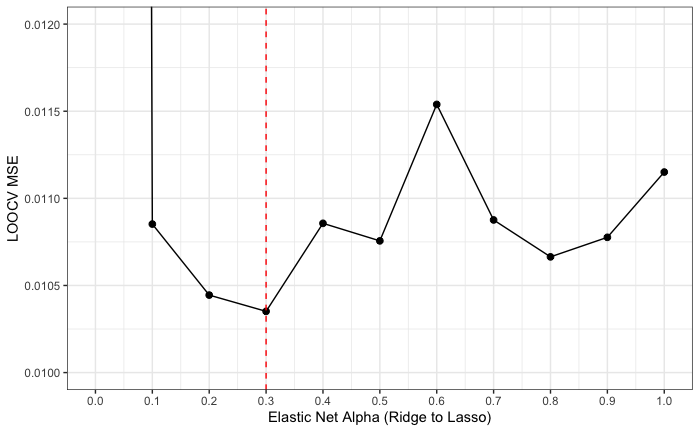

```r
# Plot CV results
ggplot(cv_results, aes(x = alpha, y = cv_error)) +
  geom_line() +
  geom_point(size = 2) +

  geom_vline(xintercept = optimal_alpha, color = "red", linetype = "dashed") +

  labs(
    y = "LOOCV MSE",
    x = "Elastic Net Alpha (Ridge to Lasso)"
  ) +
  theme_bw() +
  coord_cartesian(ylim=c(0.01,0.012)) +
  scale_x_continuous(breaks = seq(0, 1, 0.1))
```

# Case 1: Sampling w Precise Means*

- Fix latent sd to 0.2.
- Latent mean for each car is equal to it’s actual value at that dimension.

## Functions

```r
# Generate dataset
Gen_Precise_Data <- function(nSamples=10, nCars=100, truth=data.frame(), lat_sd=0.2) {
  Sampled_Data = data.frame()

  for (i in c(1:nSamples)) {
    .X1_Sampled = rnorm(nCars, mean=truth$X1, sd=lat_sd)
    .X2_Sampled = rnorm(nCars, mean=truth$X2, sd=lat_sd)
    .X3_Sampled = rnorm(nCars, mean=truth$X3, sd=lat_sd)
    .X4_Sampled = rnorm(nCars, mean=truth$X4, sd=lat_sd)
    .new_df = data.frame(
      NAcc=truth$NAcc,
      X1=.X1_Sampled, X2=.X2_Sampled, X3=.X3_Sampled, X4=.X4_Sampled
    )
    Sampled_Data = bind_rows(Sampled_Data, .new_df)
  }

  # Prepare data for glmnet (needs matrix format)
  X <- Sampled_Data[,c("X1","X2","X3","X4")] %>% as.matrix()
  Y <- Sampled_Data$NAcc %>% as.matrix()

  # Return as a list
  return(list(X=X, Y=Y))
}
```

```r
# Get best alpha for elastic net
Get_Elastic_Alpha <- function(Y=matrix(), X=matrix(), truth=data.frame()) {

  # Define alpha values to test
  alpha_values <- seq(0.05, 1, by = 0.05)

  # Placeholder
  cv_results <- data.frame(alpha = alpha_values, cv_error = NA)

  for(i in 1:length(alpha_values)) {
    # Fit model with current alpha using LOOCV
    cv_fit <- cv.glmnet(
      x = X,
      y = Y,
      alpha = alpha_values[i],
      nfolds = nrow(truth),  # LOOCV: nfolds = number of observations
      type.measure = "mse",   # Use mean squared error
      grouped = F
    )

    # Store the minimum CV error
    cv_results$cv_error[i] <- min(cv_fit$cvm)
  }

  # Find optimal alpha
  optimal_alpha <- cv_results$alpha[which.min(cv_results$cv_error)]
  return(list(alpha=optimal_alpha, cv=cv_results))
}
```

```r
# Print elastic net coefficients
Plot_Elastic_Coef <- function(Y, X, optimal_alpha, title) {

  # Fit final model with optimal alpha
  final_cv_fit <- cv.glmnet(
    x = X,
    y = Y,
    alpha = optimal_alpha,
    nfolds = nrow(X),
    type.measure = "mse",
    grouped = F
  )

  # Extract coefficients at lambda.min
  final_coefficients <- coef(final_cv_fit, s = "lambda.1se")

  # Extract coefficients and create data frame for plotting
  coef_df <- data.frame(
    variable = rownames(final_coefficients),
    coefficient = as.vector(final_coefficients),
    true_value = c(beta0, beta1, beta2, 0, 0)  # True values: intercept, X1, X2, X3, X4
  )

  # Plot coefficients vs true values
  p = ggplot(coef_df, aes(x = variable)) +
    geom_col(aes(y = coefficient, fill = "Estimated"), alpha = 0.7, width = 0.6) +
    geom_point(aes(y = true_value, color = "True Value"), size = 3) +
    geom_hline(yintercept = 0, linetype = "dashed", alpha = 0.5) +
    labs(
      title = title,
      y = "Coefficient Value"
    ) +
    scale_fill_manual(values = c("Estimated" = "steelblue")) +
    scale_color_manual(values = c("True Value" = "red")) +
    theme_minimal() +
    theme(
      legend.title = element_blank(),
      axis.title.x = element_blank()
    )

  return(p)
}
```

## Results: Latent sd & nSamples

lat_sd = .2, N = 5

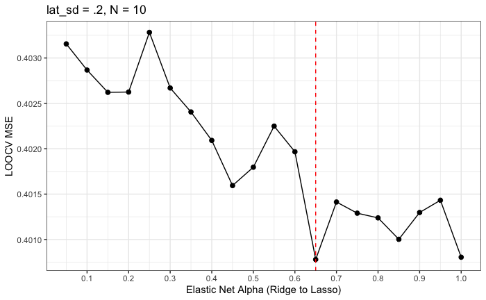

```r
set.seed(4)
nSamples = 5
lat_sd = 0.2

Data = Gen_Precise_Data(nSamples=nSamples, nCars=nCars, truth=truth, lat_sd=lat_sd)
X = Data$X
Y = Data$Y

alpha_results = Get_Elastic_Alpha(Y, X, truth)
optimal_alpha = alpha_results$alpha
cv_results = alpha_results$cv

c1p1 = Plot_Elastic_Coef(Y, X, optimal_alpha, title = "lat_sd = .2, N = 5")

# Plot CV results
ggplot(cv_results, aes(x = alpha, y = cv_error)) +
  geom_line() +
  geom_point(size = 2) +

  geom_vline(xintercept = optimal_alpha, color = "red", linetype = "dashed") +

  labs(
    title = "lat_sd = .2, N = 10",
    y = "LOOCV MSE",
    x = "Elastic Net Alpha (Ridge to Lasso)"
  ) +
  theme_bw() +
  scale_x_continuous(breaks = seq(0, 1, 0.1))
```

lat_sd = .2, N = 100

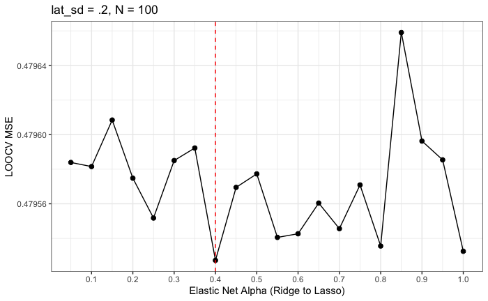

```r
set.seed(4)
nSamples = 100
lat_sd = 0.2

Data = Gen_Precise_Data(nSamples=nSamples, nCars=nCars, truth=truth, lat_sd=lat_sd)
X = Data$X
Y = Data$Y

alpha_results = Get_Elastic_Alpha(Y, X, truth)
optimal_alpha = alpha_results$alpha
cv_results = alpha_results$cv

c1p2 = Plot_Elastic_Coef(Y, X, optimal_alpha, title = "lat_sd = .2, N = 100")

# Plot CV results
ggplot(cv_results, aes(x = alpha, y = cv_error)) +
  geom_line() +
  geom_point(size = 2) +

  geom_vline(xintercept = optimal_alpha, color = "red", linetype = "dashed") +

  labs(
    title = "lat_sd = .2, N = 100",
    y = "LOOCV MSE",
    x = "Elastic Net Alpha (Ridge to Lasso)"
  ) +
  theme_bw() +
  scale_x_continuous(breaks = seq(0, 1, 0.1))
```

lat_sd = .5, N = 5

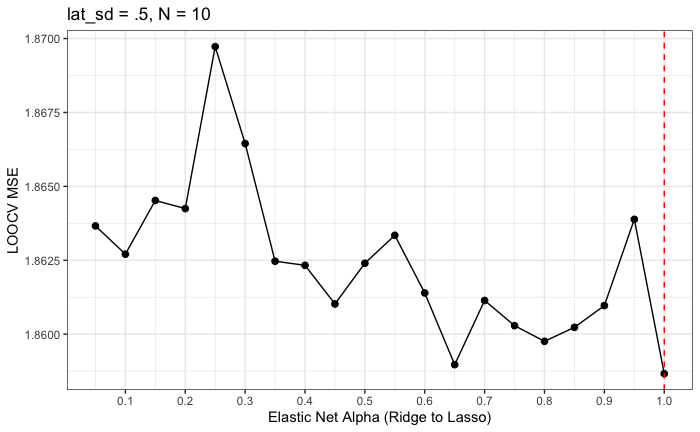

```r
set.seed(4)
nSamples = 5
lat_sd = 0.5

Data = Gen_Precise_Data(nSamples=nSamples, nCars=nCars, truth=truth, lat_sd=lat_sd)
X = Data$X
Y = Data$Y

alpha_results = Get_Elastic_Alpha(Y, X, truth)
optimal_alpha = alpha_results$alpha
cv_results = alpha_results$cv

c1p3 = Plot_Elastic_Coef(Y, X, optimal_alpha, title = "lat_sd = .5, N = 5")

# Plot CV results
ggplot(cv_results, aes(x = alpha, y = cv_error)) +
  geom_line() +
  geom_point(size = 2) +

  geom_vline(xintercept = optimal_alpha, color = "red", linetype = "dashed") +

  labs(
    title = "lat_sd = .5, N = 10",
    y = "LOOCV MSE",
    x = "Elastic Net Alpha (Ridge to Lasso)"
  ) +
  theme_bw() +
  scale_x_continuous(breaks = seq(0, 1, 0.1))
```

lat_sd = .5, N = 100

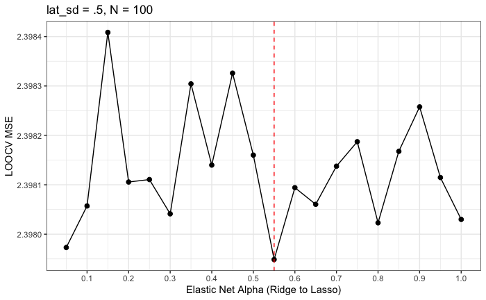

```r
set.seed(4)
nSamples = 100
lat_sd = 0.5

Data = Gen_Precise_Data(nSamples=nSamples, nCars=nCars, truth=truth, lat_sd=lat_sd)
X = Data$X
Y = Data$Y

alpha_results = Get_Elastic_Alpha(Y, X, truth)
optimal_alpha = alpha_results$alpha
cv_results = alpha_results$cv

c1p4 = Plot_Elastic_Coef(Y, X, optimal_alpha, title = "lat_sd = .5, N = 100")

# Plot CV results
ggplot(cv_results, aes(x = alpha, y = cv_error)) +
  geom_line() +
  geom_point(size = 2) +

  geom_vline(xintercept = optimal_alpha, color = "red", linetype = "dashed") +

  labs(
    title = "lat_sd = .5, N = 100",
    y = "LOOCV MSE",
    x = "Elastic Net Alpha (Ridge to Lasso)"
  ) +
  theme_bw() +
  scale_x_continuous(breaks = seq(0, 1, 0.1))
```

### Combine Plots*

Coefficients are estimated with bias towards 0 as latent standard deviation grows. Despite not having confidence intervals, we can see X1 and X2 are still estimated quite away from 0 compared to X3 and X4.

This suggests we may be able to determine which variables are significant in NAcc activity, though we may not be able to accurately say how much each variable contributes to activity.

```r
p_Case1 = (c1p1 + c1p2) / (c1p3 + c1p4) +
  plot_layout(guides = "collect")
```

|  | t | l | b | r |
| --- | --- | --- | --- | --- |
| 1: | 1 | 1 | 1 | 1 |
| 2: | 1 | 2 | 1 | 2 |

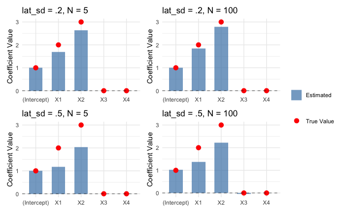

```r
plot(p_Case1)
```

## Supp: Sampling More & Uneven sd

lat_sd = .5, N = 300*

Sampling more does not eliminate the bias in recovered parameters.

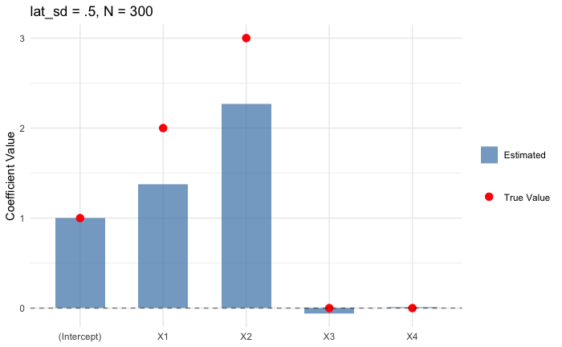

```r
set.seed(4)
nSamples = 300
lat_sd = 0.5

Data = Gen_Precise_Data(nSamples=nSamples, nCars=nCars, truth=truth, lat_sd=lat_sd)
X = Data$X
Y = Data$Y

alpha_results = Get_Elastic_Alpha(Y, X, truth)
optimal_alpha = alpha_results$alpha
cv_results = alpha_results$cv

Plot_Elastic_Coef(Y, X, optimal_alpha, title = "lat_sd = .5, N = 300")
```

lat_sd (.5,.2), N = 100*

Results are robust even if the true variables have wider latent sd than the fake variables.

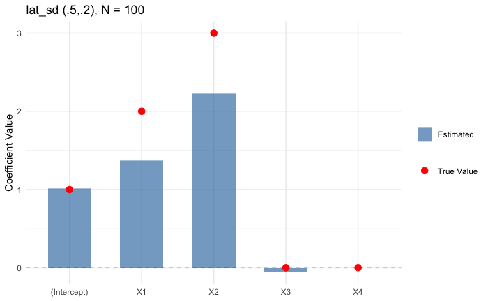

```r
set.seed(4)
nSamples = 100

Sampled_Data = data.frame()

for (i in c(1:nSamples)) {
  .X1_Sampled = rnorm(nCars, mean=truth$X1, sd=.5)
  .X2_Sampled = rnorm(nCars, mean=truth$X2, sd=.5)
  .X3_Sampled = rnorm(nCars, mean=truth$X3, sd=.2)
  .X4_Sampled = rnorm(nCars, mean=truth$X4, sd=.2)
  .new_df = data.frame(
    NAcc=truth$NAcc,
    X1=.X1_Sampled, X2=.X2_Sampled, X3=.X3_Sampled, X4=.X4_Sampled
  )
  Sampled_Data = bind_rows(Sampled_Data, .new_df)
}

# Prepare data for glmnet (needs matrix format)
X <- Sampled_Data[,c("X1","X2","X3","X4")] %>% as.matrix()
Y <- Sampled_Data$NAcc %>% as.matrix()

alpha_results = Get_Elastic_Alpha(Y, X, truth)
optimal_alpha = alpha_results$alpha
cv_results = alpha_results$cv

Plot_Elastic_Coef(Y, X, optimal_alpha, title="lat_sd (.5,.2), N = 100")
```

# Case 2: Sampling w Noisy Means*

What if our latent means are not centered on the true latent value of the car? We introduce noise to the mean, lat_mu_noise.

Theoretically, this should be the same thing as adding noise to the latent distribution. This is because X~N(m1, v1), where m1~N(m2, v2), is the same as X~N(m2, v1+v2).

## Functions

```r
# Generate dataset
Gen_Noisy_Data <- function(
    nSamples=10, nCars=100, truth=data.frame(), lat_sd=0.2, lat_mu_noise=0.2
  ) {

  Sampled_Data = data.frame()

  for (i in c(1:nSamples)) {
    .X1_Sampled = rnorm(nCars, mean=rnorm(nCars,truth$X1,lat_mu_noise), sd=lat_sd)
    .X2_Sampled = rnorm(nCars, mean=rnorm(nCars,truth$X2,lat_mu_noise), sd=lat_sd)
    .X3_Sampled = rnorm(nCars, mean=rnorm(nCars,truth$X3,lat_mu_noise), sd=lat_sd)
    .X4_Sampled = rnorm(nCars, mean=rnorm(nCars,truth$X4,lat_mu_noise), sd=lat_sd)
    .new_df = data.frame(
      NAcc=truth$NAcc,
      X1=.X1_Sampled, X2=.X2_Sampled, X3=.X3_Sampled, X4=.X4_Sampled
    )
    Sampled_Data = bind_rows(Sampled_Data, .new_df)
  }

  # Prepare data for glmnet (needs matrix format)
  X <- Sampled_Data[,c("X1","X2","X3","X4")] %>% as.matrix()
  Y <- Sampled_Data$NAcc %>% as.matrix()

  # Return as a list
  return(list(X=X, Y=Y))
}
```

## Results: Source of Noise

lat_sd = .2, mu_sd = .2, N = 100

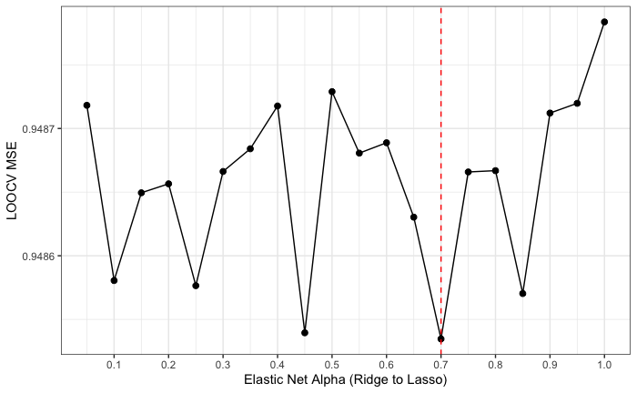

```r
set.seed(4)
nSamples = 100
lat_sd = 0.2
mu_sd = 0.2

Data = Gen_Noisy_Data(nSamples=nSamples, nCars=nCars, truth=truth,
                      lat_sd=lat_sd, lat_mu_noise=mu_sd)
X = Data$X
Y = Data$Y

alpha_results = Get_Elastic_Alpha(Y, X, truth)
optimal_alpha = alpha_results$alpha
cv_results = alpha_results$cv

c2p1 = Plot_Elastic_Coef(Y, X, optimal_alpha, title="lat_sd = .2, mu_sd = .2, N = 100")

# Plot CV results
ggplot(cv_results, aes(x = alpha, y = cv_error)) +
  geom_line() +
  geom_point(size = 2) +

  geom_vline(xintercept = optimal_alpha, color = "red", linetype = "dashed") +

  labs(
    y = "LOOCV MSE",
    x = "Elastic Net Alpha (Ridge to Lasso)"
  ) +
  theme_bw() +
  scale_x_continuous(breaks = seq(0, 1, 0.1))
```

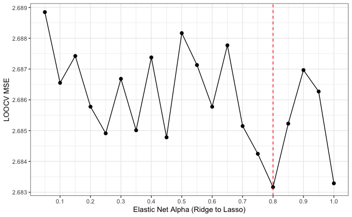

```r
set.seed(4)
nSamples = 10
lat_sd = 0.2
mu_sd = 0.5

Data = Gen_Noisy_Data(nSamples=nSamples, nCars=nCars, truth=truth,
                      lat_sd=lat_sd, lat_mu_noise=mu_sd)
X = Data$X
Y = Data$Y

alpha_results = Get_Elastic_Alpha(Y, X, truth)
optimal_alpha = alpha_results$alpha
cv_results = alpha_results$cv

c2p2 = Plot_Elastic_Coef(Y, X, optimal_alpha, title="lat_sd = .2, mu_sd = .5, N = 100")

# Plot CV results
ggplot(cv_results, aes(x = alpha, y = cv_error)) +
  geom_line() +
  geom_point(size = 2) +

  geom_vline(xintercept = optimal_alpha, color = "red", linetype = "dashed") +

  labs(
    y = "LOOCV MSE",
    x = "Elastic Net Alpha (Ridge to Lasso)"
  ) +
  theme_bw() +
  scale_x_continuous(breaks = seq(0, 1, 0.1))
```

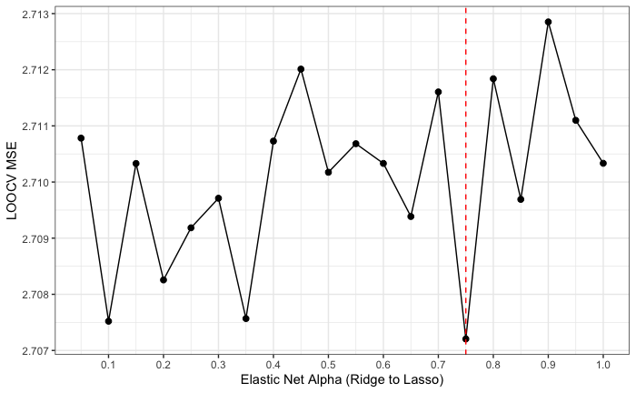

```r
set.seed(4)
nSamples = 10
lat_sd = 0.5
mu_sd = 0.2

Data = Gen_Noisy_Data(nSamples=nSamples, nCars=nCars, truth=truth,
                      lat_sd=lat_sd, lat_mu_noise=mu_sd)
X = Data$X
Y = Data$Y

alpha_results = Get_Elastic_Alpha(Y, X, truth)
optimal_alpha = alpha_results$alpha
cv_results = alpha_results$cv

c2p3 = Plot_Elastic_Coef(Y, X, optimal_alpha, title="lat_sd = .5, mu_sd = .2, N = 100")

# Plot CV results
ggplot(cv_results, aes(x = alpha, y = cv_error)) +
  geom_line() +
  geom_point(size = 2) +

  geom_vline(xintercept = optimal_alpha, color = "red", linetype = "dashed") +

  labs(
    y = "LOOCV MSE",
    x = "Elastic Net Alpha (Ridge to Lasso)"
  ) +
  theme_bw() +
  scale_x_continuous(breaks = seq(0, 1, 0.1))
```

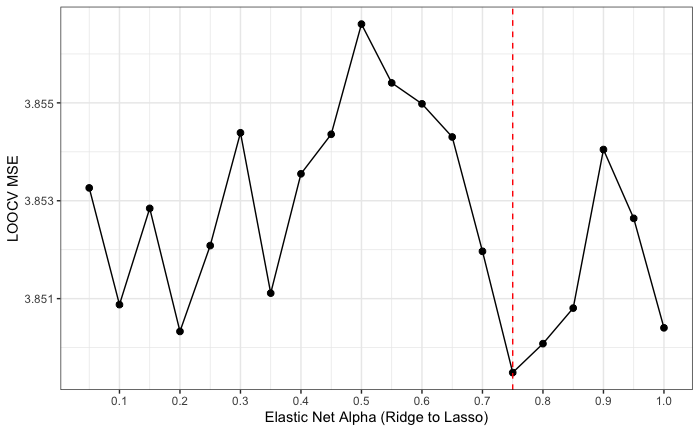

```r
set.seed(4)
nSamples = 10
lat_sd = 0.5
mu_sd = 0.5

Data = Gen_Noisy_Data(nSamples=nSamples, nCars=nCars, truth=truth,
                      lat_sd=lat_sd, lat_mu_noise=mu_sd)
X = Data$X
Y = Data$Y

alpha_results = Get_Elastic_Alpha(Y, X, truth)
optimal_alpha = alpha_results$alpha
cv_results = alpha_results$cv

c2p4 = Plot_Elastic_Coef(Y, X, optimal_alpha, title="lat_sd = .5, mu_sd = .5, N = 100")

# Plot CV results
ggplot(cv_results, aes(x = alpha, y = cv_error)) +
  geom_line() +
  geom_point(size = 2) +

  geom_vline(xintercept = optimal_alpha, color = "red", linetype = "dashed") +

  labs(
    y = "LOOCV MSE",
    x = "Elastic Net Alpha (Ridge to Lasso)"
  ) +
  theme_bw() +
  scale_x_continuous(breaks = seq(0, 1, 0.1))
```

### Combine Plots*

Confirming that where the noise enters in is irrelevant, since the addition of two random normal variables equals a random normal variable with the variances summed.

Results are similar to Case 1. We have larger bias, but we’re still able to distinguish which variables are true versus fake.

```r
p_Case2 = (c2p1 + c2p2) / (c2p3 + c2p4) +
  plot_layout(guides = "collect")
```

|  | t | l | b | r |
| --- | --- | --- | --- | --- |
| 1: | 1 | 1 | 1 | 1 |
| 2: | 1 | 2 | 1 | 2 |

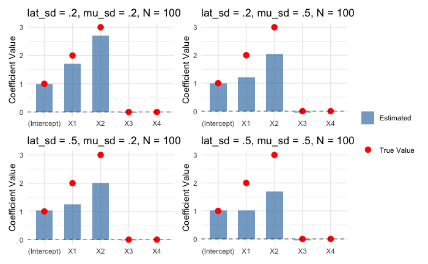

```r
plot(p_Case2)
```

## Supp: Limit of sd*

Based on the last result, we don’t need to differentiate between lat_sd and mu_sd. But where is the limit of lat_sd?

lat_sd = .75, N = 100

```r
set.seed(4)
nSamples = 100
lat_sd = .75

Data = Gen_Precise_Data(nSamples=nSamples, nCars=nCars, truth=truth, lat_sd=lat_sd)
X = Data$X
Y = Data$Y

alpha_results = Get_Elastic_Alpha(Y, X, truth)
optimal_alpha = alpha_results$alpha
cv_results = alpha_results$cv

c2sp1 = Plot_Elastic_Coef(Y, X, optimal_alpha, title = "lat_sd = .75, N = 100")
```

lat_sd = 1, N = 100

```r
set.seed(4)
nSamples = 100
lat_sd = 1

Data = Gen_Precise_Data(nSamples=nSamples, nCars=nCars, truth=truth, lat_sd=lat_sd)
X = Data$X
Y = Data$Y

alpha_results = Get_Elastic_Alpha(Y, X, truth)
optimal_alpha = alpha_results$alpha
cv_results = alpha_results$cv

c2sp2 = Plot_Elastic_Coef(Y, X, optimal_alpha, title = "lat_sd = 1, N = 100")
```

lat_sd = 1.5, N = 100

```r
set.seed(4)
nSamples = 100
lat_sd = 1.5

Data = Gen_Precise_Data(nSamples=nSamples, nCars=nCars, truth=truth, lat_sd=lat_sd)
X = Data$X
Y = Data$Y

alpha_results = Get_Elastic_Alpha(Y, X, truth)
optimal_alpha = alpha_results$alpha
cv_results = alpha_results$cv

c2sp3 = Plot_Elastic_Coef(Y, X, optimal_alpha, title = "lat_sd = 1.5, N = 100")
```

lat_sd = 3, N = 100

```r
set.seed(4)
nSamples = 100
lat_sd = 3

Data = Gen_Precise_Data(nSamples=nSamples, nCars=nCars, truth=truth, lat_sd=lat_sd)
X = Data$X
Y = Data$Y

alpha_results = Get_Elastic_Alpha(Y, X, truth)
optimal_alpha = alpha_results$alpha
cv_results = alpha_results$cv

c2sp4 = Plot_Elastic_Coef(Y, X, optimal_alpha, title = "lat_sd = 3, N = 100")
```

### Combine Plots*

By about lat_sd = 3, we start to question whether X1 and X2 are significant.

```r
p_Case2_Supp1 = (c2sp1 + c2sp2) / (c2sp3 + c2sp4) +
  plot_layout(guides = "collect")
```

|  | t | l | b | r |
| --- | --- | --- | --- | --- |
| 1: | 1 | 1 | 1 | 1 |
| 2: | 1 | 2 | 1 | 2 |

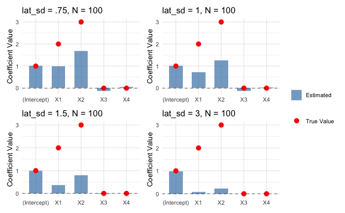

```r
plot(p_Case2_Supp1)
```